ProTN is an integrative pipeline that analyze DDA proteomics data obtained from MS. It perform a complete analysis of the raw files from [Proteome Discoverer](https://www.thermofisher.com/it/en/home/industrial/mass-spectrometry/liquid-chromatography-mass-spectrometry-lc-ms/lc-ms-software/multi-omics-data-analysis/proteome-discoverer-software.html) (PD) or [MaxQuant](https://maxquant.org/) (MQ), with their biological interpretation with enrichement and network analysis. ProTN executes a dual level analysis, at protein and peptide level.

## 1. Workflow of ProTN

- Later in this section we describes in details the workflow of the pipeline. In the first phases it imputes and normalizes the data obtaining the matrix that is used in the enrichment analysis of the proteins. The enrichment perform a complete analysis and a PPI network analysis. During the enrichment steps, the only protein analyzed are the up- or down-regulated, discriminated by the following parameters.

### 1.2. Normalization of the intensities

  The intensities are log2 transformed and normalized with DEqMS (Zhu 2022). Two methods are applied because a double normalization is required, one for peptides and one for proteins. At the peptide level, the normalization is done by the function equalMedianNormalization, which normalizes intensity distributions in samples so that they have median equal to 0.

  At the protein level, this operation is executed by the function medianSweeping. It applies the same median normalization used for peptides, but also it summarizes the peptide intensities into protein relative abundance by the median sweeping method.

[figure not shown]

### 1.3. Imputation of the intensities

  After the normalization the intensities from Mass Spectrometer need to be imputed. The principal method is based on the PhosR package (Kim et al. 2021) that performs a complex and well-balanced imputation of the data based on the conditions of the samples. As a backup method in case of problems with PhosR imputations, ProTN uses a Gaussian round imputation.

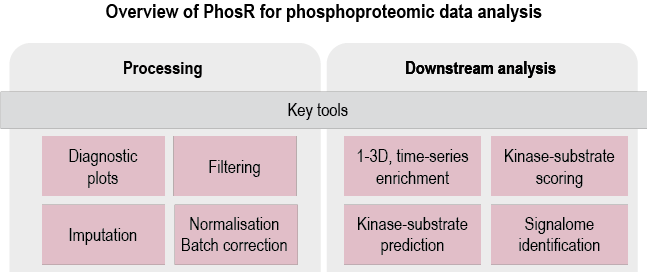

  In this step, two MDSs and two PCAs (proteins and peptides) are generated.

### 1.4. Batch Effect correction

  If required by the experiment, a batch correction step can be applyed using [proBatch](https://www.bioconductor.org/packages/release/bioc/html/proBatch.html) (Cuklina et al. 2018). The batches need to be defined in the **Input** file where column **MS_batch** is required.

### 1.5. Statistical differential analysis

  The workflow continue with the differential analysis. This phase is applied to proteins and peptides, to obtain the significant proteins and peptides. However the two methodologies are slightly different since for proteins is used the DEqMS package (Zhu 2022), instead, for peptides is used the usual Limma package (Ritchie et al. 2015). DEqMS is developed on top of Limma, but the method estimates different prior variances for proteins quantified by different numbers of PSMs/peptides per protein, therefore achieving better accuracy.

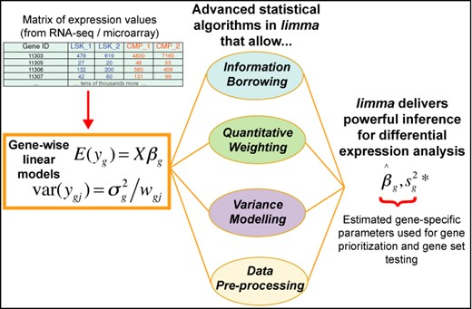

  Limma and DEqMS calculate DEPs for each comparison in the *design* file parameter. Each peptide or protein has different parameters: the log2 Fold Change, the P.Value, the adjusted P.Value and the log2 expression. In this pipeline, a protein/peptide is significant if passing 3 thresholds. A protein/peptide for each comparison can be Up-regulated or Down-regulated. It is Up-regulated if:
  - the log2 FC is higher than the Fold Change threshold (FC > Log2 FC thr),
  - the P.Value is lower than the threshold (P.Value < P.Value thr),
  - the log2 expression is higher than the threshold (log2 expression > Signal log2 expr thr).

  It is Down-regulated if:
  - the log2 FC is lower of the Fold Change threshold (FC < -Log2 FC thr),
  - the P.Value is lower than the threshold (P.Value < P.Value thr),
  - the log2 expression is higher than the threshold (log2 expression > Signal log2 expr thr).

  In the output, for each comparison, this distinction is reported in the “*class*” column, which assumes value “+” if is up-regulated, “-” if down-regulated and “=” if it is not significant.

  Various figures are generated, first a bar plot that graphically represents the DEPs identified. Followed by comparison-specific volcano plots.

### 1.6. Enrichment analysis of the Differentially Expressed Proteins

  The biological interpretation of the Differentially Expressed Proteins starts with the enrichment step. To execute this analysis, ProTN uses [EnrichR](https://maayanlab.cloud/Enrichr/) (Jawaid 2022), a widely used tool that search on a large number of data sets to obtain information about many categories. EnrichR organises its hundreds of data sets in 8 sections: Transcription, Pathways, Ontologies, Diseases/Drugs, Cell Types, Misc, Legacy, and Crowd.

[figure not shown]

  Since the analysis that a user wants to perform can be different, each comparison has 3 sets of proteins: the Up-regulated (called Up), the Down-regulated (called Down), and the set (called all) obtained by the merge of Up- and Down-regulated proteins. EnrichR provides for each term much information. It returns the statistical parameters, like P.Value, fdr, odds ratio and combined score. At the same time, it gives the overlap size, the number of genes in the term and the genes of the input list find in the term.

  The tons of data downloaded from EnrichR are exported in two modalities. The tool creates an *RData* of the complete data frame, in this way the user can easily import in R to perform further analysis and plots. But also, it generates an *Excel* file with only the significant terms. The process uses the filters define in the options file to differentiate the relevant terms from the globality.

  A term to be significative need to have:
  - a P.Value lower of P.Value thr for enrichment (P.Value < P.Value thr for enrichment),
  - an Overlap Size higher than Overlap size thr for enrichment (Overlap Size > Overlap size thr for enrichment).

  Besides that, the pipeline plots the enrichment results in different figures. The 4 plots can be split into 2 categories. The first two are filtered on the data-sets, they illustrate only the data-sets written in the column DB to analyse of the options file. The other 2 are filtered on words to search on the term description, it uses the list of words in column Terms to search.

### 1.7. Protein-Protein Interaction network analysis of Differentially Expressed Proteins

  Last analitical step is the Protein-Protein Interaction (PPI) network analysis, since PPIs are essential in almost all processes of the cell, and it is crucial for understanding cell physiology in different states. For each comparison, ProTN analyses the interaction between the DEPs using [STRING](https://string-db.org/) (Szklarczyk et al. 2021).

[figure not shown]

  The species-specific database is retrieved from STRING server, an accurate analysis discover all the interactions and an iGraph (Csardi and Nepusz 2006) network is generated. Later, the proteins are clustered via iGraph function which identify dense subgraph by optimizing modularity score.

  Since the network can vary a lot on composition, two ggplot layout are used: Fruchterman-Reingold algorithm and the Kamada-Kawai algorithm.

## 3. Details on the input parameters and files

- - `Title of Analysis`: title of the experiment. It will be the title of the web page report.
  - `Brief Description`: description of the current experiment. It is the first paragraph of the report.
  - `Software Analyzer`: determine with software was use to identify peptides and proteins. **PD** for Protein Discoverer, **MQ** for MaxQuant.
  - `Input file`: file with the information about the samples and the correlation between replicate ID and condition. The **Input** file is an Excel file with the following column :
    - **Condition** column (`REQUIRED`): define the condition of each sample that divide the samples in groups. The conditions need to be the same of the the Contrast Design. In the example the two condition are DMSO and TRT.
    - **Color** columns (`OPTIONAL`): define a color for the samples in the graphs. If not present use a default palette.
    - **MS_batch** columns: define the groups of batch in the samples. `REQUIRED FOR BATCH EFFECT CORRECTION`.
    - **Sample** column: define the names for the samples.
      - In case of **PD** files use the *Input* file obtained from PD, an example of PD Input file is present in *file_input_raw/Input_filter.xlsx*, the **Sample** column in optional, if is not present the software extract the names for the **“File Name”** column.
      - In case of **MQ** analysis the this column is `REQUIRED`
  - `Peptides file`: raw file of peptides obtained from PD or MQ (file **peptides.txt**).
  - `Proteins file`: raw file of protein groups obtained from PD or MQ (file **proteinGroups.txt**).
  - `Design for the comparison file`: Excel file containing the formulas of the contrast comparison you want to analyse. The table can have 3 columns :
    - **Formule** column (`REQUIRED`): The formulas need to follow the syntax of [Limma](https://bioinf.wehi.edu.au/limma/). `AT LEAST 1 FORMULA IS REQUIRED`.
    - **Name** column (`OPTIONAL`): personalized name assign to the comparison.
    - **Color** columns (`OPTIONAL`): define a color for the condition in the graphs. If not present use a default palette.
  - `OPTIONAL`:
    - **Signal log2 expr thr**: signal log2 expression threshold for the differential analysis. *DEFAULT:* DEPs if `Signal log2 expression threshold > -∞` (No Limit, represent by value “inf” in the cell)
    - **Log2 FC thr**: Fold Change threshold for the differential analysis. *DEFAULT:* DEPs if `log2 Fold Change threshold = 0.75` (Up-regulated > 0.75, Down-regulated < -0.75)
    - **P.Value thr**: p.value threshold for the differential analysis. *DEFAULT:* DEPs if `P value threshold < 0.05`
    - **Batch Correction**: execution of the batch effect correction performed by [proBatch](https://www.bioconductor.org/packages/release/bioc/html/proBatch.html). (Cuklina et al. 2018). (**TRUE** or **FALSE**). If **TRUE**, column **MS_batch** required in **Input** file.
    - **Control Boxplot proteins**: list of proteins used as control of the intensities. For each protein a boxplot is generated comparing the mean of the intensities group by condition.
    - **Execute Enrichment**: boolean value for the execution of the enrichment step. (**TRUE** or **FALSE**)
    - **Execute PPI network STRINGdb**: boolean value for the execution of the network analysis. (**TRUE** or **FALSE**)
    - **P.Value thr for enrichment**: p.value threshold of the enriched terms. **DEFAULT:** Term is significant if `P Value threshold for Enrichment < 0.05`
    - **Overlap size thr for enrichment**: Overlap size threshold. The overlap size is the number of DEPs discovered in the enriched terms. **DEFAULT:** Term is significant if `Minimum number of overlap genes with enriched terms > 5`
    - **Enrichment**: determine of filter the plot of the enrichment results. The enrichment can be filter by terms or by DBs. In the column *“Terms to search”* you can write the word that you want to search in the results of EnrichR (EX: MYC, C-MYC, Senescence,…). Instead, in the column *“DB to analyse”* you can write the DBs that you want to see in your plots (EX: ChEA_2016, KEGG_2021_Human, BioPlanet_2019, GO_Biological_Process_2021,…), using the same name that you can find in EnrichR. If the two columns are empty, no plots of enrichment are returned.

## 4. Example case study - Proteomics of MCF7 cells

- `Proteomics of MCF7 cells (LC-MS/MS Orbitrap Fusion Tribrid)`

  PRIDE: PXD009417.

  Clamer M, Tebaldi T, Lauria F, et al. Active Ribosome Profiling with RiboLace. Cell Rep. 2018;25(4):1097-1108.e5.

  Its execution is performed clicking the button **Case Study Example**.

Csardi, Gabor, and Tamas Nepusz. 2006. “The Igraph Software Package for Complex Network Research” Complex Systems: 1695. https://igraph.org.

Cuklina, Jelena, Chloe H. Lee, Evan G. Willams, Ben Collins, Tatjana Sajic, Patrick Pedrioli, Maria Rodriguez-Martinez, and Ruedi Aebersold. 2018. “Computational Challenges in Biomarker Discovery from High-Throughput Proteomic Data.” https://doi.org/10.3929/ethz-b-000307772.

Jawaid, Wajid. 2022. “enrichR: Provides an r Interface to ’Enrichr’.” https://CRAN.R-project.org/package=enrichR.

Kim, Hani Jieun, Taiyun Kim, Nolan J Hoffman, Di Xiao, David E James, Sean J Humphrey, and Pengyi Yang. 2021. “PhosR Enables Processing and Functional Analysis of Phosphoproteomic Data” 34. https://doi.org/10.1016/j.celrep.2021.108771.

Ritchie, Matthew E, Belinda Phipson, Di Wu, Yifang Hu, Charity W Law, Wei Shi, and Gordon K Smyth. 2015. “Limma Powers Differential Expression Analyses for RNA-Sequencing and Microarray Studies” 43: e47. https://doi.org/10.1093/nar/gkv007.

Szklarczyk, Damian, Annika L Gable, Katerina C Nastou, David Lyon, Rebecca Kirsch, Sampo Pyysalo, Nadezhda T Doncheva, et al. 2021. “The STRING Database in 2021: Customizable Protein-Protein Networks, and Functional Characterization of User-Uploaded Gene/Measurement Sets.” 49.

Zhu, Yafeng. 2022. “DEqMS: A Tool to Perform Statistical Analysis of Differential Protein Expression for Quantitative Proteomics Data.”